# HW2 Alvaro Martin

```r
# This are the best hyperparameters:
parametros2[bestpos,]
```

|  | mtry | ntree |
| --- | --- | --- |
| 31 | 2 | 250 |

Before we test the performance of the model, let’s see how the performance of the model changes with respect to the hyperparameters we select:

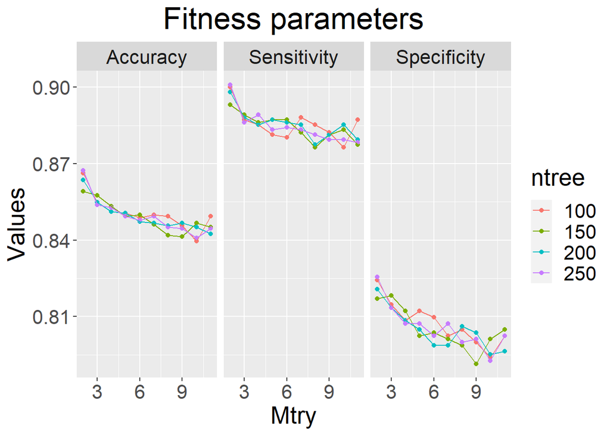

```r
auxdata = data.frame(Values=c(cv_hyper2[1,],cv_hyper2[2,],cv_hyper2[3,]),
                     Parameters=c(rep('Accuracy',length(cv_hyper2[1,])),
                                  rep('Sensitivity',length(cv_hyper2[1,])),
                                  rep('Specificity',length(cv_hyper2[1,]))),
                     Hyperparameters=rbind(parametros2,parametros2,parametros2))
auxdata$Parameters=as.factor(auxdata$Parameters)

ggplot(data=auxdata)+aes(x=Hyperparameters.mtry,y=Values,color=as.factor(Hyperparameters.ntree))+
  geom_point()+geom_line()+facet_wrap(Parameters~.)+
  labs(title="Fitness parameters",x="Mtry",color="ntree")+
  theme(plot.title=element_text(size=25,hjust=0.5),text=element_text(size=20))
```

```r
# We see that our model predicts worse with a higher value for mtry.
```

So the performance of the random forest with the best combinations of ntree and mtry is:

```r
bestclassifier = randomForest(formula=HeartDisease ~.,
                              data=training,
                              mtry = parametros2[bestpos,1],
                              ntree = parametros2[bestpos,2])
pred = predict(bestclassifier,testing,type="class")
CM <-confusionMatrix(pred, testing$HeartDisease)
CM$overall[1] # Accuracy
```

```
##  Accuracy
## 0.8858696
```

```r
CM$byClass[1] # Sensitivity
```

```
## Sensitivity
##   0.9215686
```

```r
CM$byClass[2] #Specificity
```

```
## Specificity
##   0.8414634
```

```r
# The results are really really good. We have obtained the biggest accuracy
# so far with a sensitivity over 90% and a high specificity as well.
```

Variable importance:

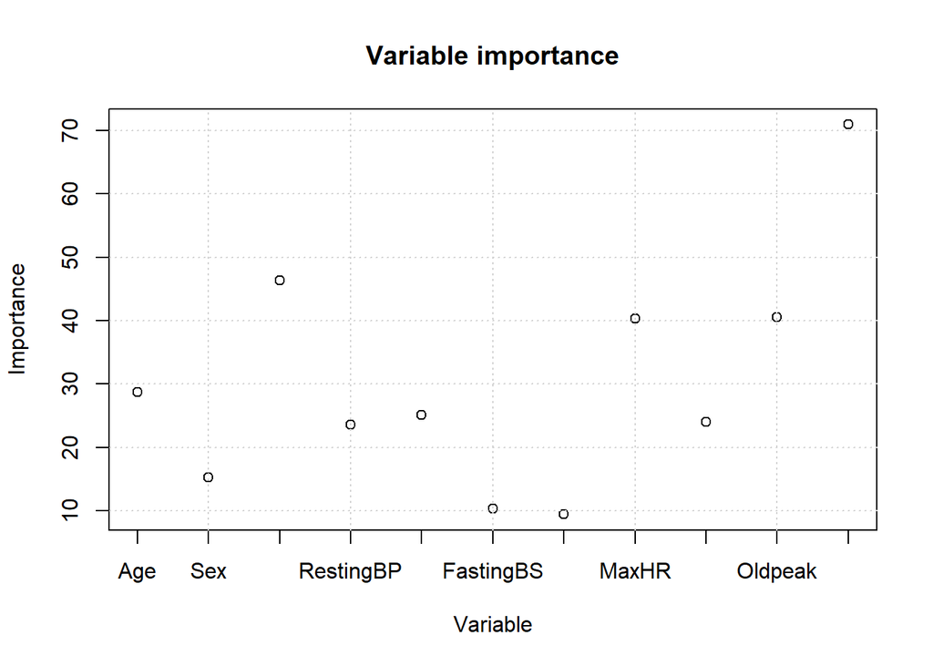

```r
plot(bestclassifier$importance,
     xaxt="n",
     xlab="Variable",ylab="Importance"
)
title("Variable importance")
axis(side=1,
     at=seq(1, length(bestclassifier$importance), by=1),
     labels = row.names(bestclassifier$importance),
)
grid()
```

```r
# As we can expect, specially ST_Slope and also ChestPainType are the most
# significant variables for our model,which coincides also with the decision tree.
```

But sometimes, the threshold in the Bayes rule is more important than hyper-parameters in the ML tools:

```r
threshold = best_threshold
rfProb = predict(bestclassifier, newdata=testing, type="prob")
rfPred = rep("Disease", nrow(testing))
rfPred[which(rfProb[,2] > threshold)] = "Not_disease"
CM = confusionMatrix(factor(rfPred), testing$HeartDisease)$table
CM
```

```
##              Reference
## Prediction    Disease Not_disease
##   Disease          94          14
##   Not_disease       8          68
```

```r
sum(diag(CM))/sum(CM) # Accuracy
```

```
## [1] 0.8804348
```

```r
CM[1,1]/sum(CM[1,]) #Precision
```

```
## [1] 0.8703704
```

```r
CM[2,2]/sum(CM[,2]) # Specificity
```

```
## [1] 0.8292683
```

```r
CM[1,1]/sum(CM[,1]) # Sensitivity
```

```
## [1] 0.9215686
```

```r
# In this case, the results obtained using the threshold (with posterior probabilities) and the ones using the classical method are similar (very good both).
```

CONCLUSION: Although more sophisticated and computational complex techniques usually give better results, this is not always the case. For example, we have seen how increasing the number of trees does not always improve the random forest, or how the decision tree that only used one variable to classify gave us similar results as other models much more complex. Not always the most complex model is the best. We have seen how finding the best possible combination of hyperparameters for the random forest is very time-demanding and does not give us much more better results. I would say that in the case of this dataset, probably using logistic regression or a decision tree would be the best choices in terms of cost and performance.